# Judicial Bias and Economic Outcomes

Author

Affiliation

Nayab Khurshaidi

University of Pennsylvania

Published

May 10, 2024

# PSCI 3800: Judicial Bias and Economic Outcomes - An Analysis of Indian States

# Introduction

India, a country rife with gender-related violence, ranks 128th of 177 countries in the Women, Peace and Security Index (WPS) curated by Georgetown, based on measures of inclusion, justice, and security in society (2024). In fact, according to a report by the Indian National Crime Records Bureau (NCRB) in India, the country records a whopping 51 cases of crime against women every hour, ranging from ‘cruelty against women’ to assault and rape (Verma 2024). In a society which is so deeply plagued by gender violence, it is incredibly important that these women have access to the proper judicial tools at their disposal in order to counteract these harsh conditions, and be able to use these judicial pathways safely, fairly, and successfully. Despite this, in the WPS Index, India receives a score of 2.4 on a scale ranging from 0 to 4 for “Access to Justice”, ranking somewhere in the middle of other countries in the region–not entirely promising given the harsh conditions women must endure (2024).

Judicial bias in the legal system is inextricably linked to other forms of gender bias in society as well, and can serve as an interesting unique avenue to view gender bias in a society. However, judicial bias is not only salient in the sphere of violent crimes against women. Reductions in gender bias in society and increase in women entering the workplace has shown to be a key indicator of increased overall productivity in society, resulting in greater economic outcomes (Holland and Ell 2023). A reduction in gender bias towards women in the workforce in the society has been causally related with an increase in GDP, due to an increase in overall productivity and specialized skills (Holland and Ell 2023). Additionally, It is well documented that a stronger, independent judiciary is an indicator of economic growth (Dam 2016). This project will attempt to examine these theories in the context of India specifically.

Two prominent studies have been conducted regarding the outcomes for women in the judicial system in India. Utilizing over 5 million lower court cases in an 8 year period, although Ash et al. (2023) found no specific in-group biases from male judges towards female defendants, Jassal (2023) does finds that women are still disadvantaged in the Indian courts through discrimination at several different levels including higher court dismissals and higher accused acquittals. Furthermore, in a judicial case review analysis by Badoni and Rahman (2022), it was found that judicial stereotyping was clearly evident through language in decisions from several cases concerning sexual violence against women, where women were described in terms of their “provocative clothing,” or of being “habitual to intercourse.” Moreover, it seems there is a general consensus in the public view of a need for judicial reform and improvements in India–in a study by Garg et al. (2024) found that 54% of people believe that a more proactive role of the Indian judiciary is “required in addressing gender-based discrimination and violence,” and 79% supported “specialized courts/tribunals to handle cases related to women’s rights.” Although judicial reform and bias is an ongoing conversation, only 2 investigations (Ash et al. 2023; Jassal 2023) utilize real case data from India’s lower courts to analyze this issue at the state-level, rather than the national level. Furthermore, the majority of the research in India focuses on qualitative reviews of case laws and decisions, rather than outcomes. My project aims to fill this gap in the literature by addressing outcomes for women using state level panel data.

Access to justice is recognized globally as a basic human right. Indeed Articles 5 through 11 of the Universal Declaration of Human Rights lay out the scope of this right to justice, and outline the rights to fair trials and punishments (n.d.a). As Sandefur (2008) highlights, access to justice can both expose and exacerbate societal inequalities. Furthermore, as UN Women highlights, women are usually the poorest and most marginalized parts of society, and often lack agency, and more robust judicial institutions create foundations for women to “assert and claim their social, economic, cultural, political and civil rights (n.d.b). The courts have long been an avenue through which marginalized groups can access rights that have been denied to them by society, or to gain equal footing with other segments of society. Therefore, the preservation of a fair and just judicial system is extremely important, and especially important for women, especially in a country such as India, where, as I have previously established, there is such a large proliferation of gender based violence. Furthermore, as I have also established, access to justice is often better for society overall economically. I aim to add on to the research in this field by zooming in on India specifically to examine these trends.

# Theory and Hypothesis

I predict that on average, lower judicial biases in states in India (measured through differences in acquittal rates between men and women) will result in higher GDP’s in those states, displaying an inverse relationship.

Research emphasizes protections and power of enforcement that is vested in the judiciary (Dam 2016). Substantial research emphasizes the interconnectedness of the legal system and economic performance. Lorizio and Gurrieri (2014) found, for example, that economic growth in Italy was negatively affected by the confidence investors, businesses and households had in the judicial system. Furthermore, a study that used panel data from 73 countries across world regions found that access to justice is a significant positive determinant of economic growth within countries (Deseau et al. 2019). Additionally, the researchers hypothesized that the impact of access to justice could possibly be stronger in less developed countries, such as India (Deseau et al. 2019). I predict, therefore, that lower judicial biases will result in an increased ability of women to have equal opportunity and legal protection, resulting in a greater participation in the workforce, an increase in the utilization of human capital, and resulting greater economic prosperity and outcomes in those states, as measured through GDP.

# Research Design

## Data

The first variable of interest is the difference in the acquittal rate for male and female defendants. This was generated by aggregating the cases that were coded for a disposition of ‘acquittal’ to the state level. The female acquittal rate was then subtracted from the male acquittal rate in order to create a difference in acquittal rate variable. The variable is positive if there was a greater male acquittal rate, and negative if there was a greater female acquittal rate. The unit is a ‘difference in rate,’ and the unit of analysis is at the state level. It is important to note that the final dataset scraped from the e-courts platform includes acquittal rate data from 28 states and 1 union territory in India. 4 union territories were excluded from the analysis, because they either did not have sufficient GDP panel data available (as was the case in Diu and Daman, Dadra Nagar Haveli, and Ladakh), or due to an active ongoing boundary dispute (as was the case in Jammu and Kashmir).

2 other variables were generated using the Indian e-Courts data. The first was the difference in the dismissal rate for female and male defendants, which was generated using similar steps as above, using cases where the disposition was a dismissal. Similarly, the difference in the conviction rate for female and male defendants was also generated. The second dataset that was used was Gross State Domestic Product panel data, from which I am using the GDP variable. This data was taken from the Government of India Ministry of Statistics and Programme Implementation, and is measured in Crores (10 millions) of Indian Rupees. The level of analysis is the state level, and the data spans from 2011 - 2023.

Summary Statistics for Key Variables

| Variable | n | mean | sd | median | min | max | range | se |
| --- | --- | --- | --- | --- | --- | --- | --- | --- |
| diff_acquittal | 224 | 2.03 | 3.16 | 1.39 | -7.90 | 13.03 | 20.93 | 0.21 |
| diff_dismissal | 224 | -4.36 | 4.05 | -3.18 | -17.25 | 4.77 | 22.02 | 0.27 |
| diff_conviction | 224 | 1.22 | 1.88 | 0.61 | -6.34 | 10.18 | 16.52 | 0.13 |
| GDP | 350 | 607560.80 | 611561.17 | 435990.67 | 7258.69 | 3108021.87 | 3100763.18 | 32689.32 |

## Regression Model

The regression model I will use to test my hypothesis is:

$$\text{GDP} = \alpha + \beta \times \text{Acquittal Rate Difference} + \varepsilon \$$

Additionally, I will include a regression model with squared terms on the IV, in an attempt to account for the U-shape of the graph of the acquittal rate.

$$\text{GDP} = \alpha + \beta \times \text{Acquittal Rate Difference} +\text{Acquittal Rate Difference}^2 + \varepsilon \$$

One covariate that I plan on including is the population growth rate. Population growth rates may have a negative affect on both judicial bias and GDP. An increase in population growth rate may cause a rapidly increasing population in states, which may put a strain on that state’s resources.It could lead to increased unemployment, and put pressure on infrastructure and social services, potentially hindering economic growth. Furthermore, in the case of judicial bias, higher population growth can lead to an increase in legal cases, putting pressure on the judicial system to handle them efficiently. Judicial systems may struggle to allocate resources equitably in regions experiencing rapid population growth, leading to disparities in access to justice and potentially exacerbating biases.

This population growth rate will be taken from the Reserve Bank of India’s Handbook of Statistics on Indian States. The years covered in the data are 2011 - 2020 and the unit of analysis is at the state level.

## Limitations

One potential unobserved confounder is the composition of the cases. For example, it is possible that women are being charged with lower severity crimes, and are therefore seeing their cases dismissed, or seeing higher rates of acquittal as a result of them. Unfortunately, the aggregated data does not indicate the type of case or allegation the defendant was facing. In future extensions of this, it would be important to examine these.

Potential unobserved confounders include political stability (political stability may lead to both a more fair judicial system and may lead to increased economic growth), income inequality (which may affect access to the legal system among disadvantaged groups, and inequality tends to discourage economic growth.)

One of the threats to interpreting this as a causal relationship is reverse causality, as it is possible that a higher GDP can lead to improvements in the legal system, such as legal training and the expansion of legal access, which may lead to lower gender and bias and a smaller difference in acquittal rates between men and women. Therefore, it is difficult to prescribe the direction of the causality.

Furthermore, there are many possible unobserved covariates and confounders due to a lack of readily available panel data for the states over the time period that the judicial bias data is available. Variables such as female labor force participation or other measures of growth would be useful in probing these results further, but are only available at the national level, rather than the state level. Furthermore, there are variables that jointly determine both acquittal rates and GDP which are not included in the data. A more comprehensive data set would be required for a more robust analysis.

## Empirical Extension Plan

In order to add credibility to my inference, I will conduct the analysis I conducted above on two different measures of judicial bias in addition to the primary “Differences in acquittal rates” variable. First, I will use the difference in dismissal rates, once again, controlling for population growth so that I can rule it out as a potential con-founder. I will then repeat the same process with the difference in conviction rates, another measure of judicial bias.

### Regression Model 2

$$\text{GDP} = \alpha + \beta_1 \times \text{Dismissal Rate Difference} + \beta_2 \times \text{Population Growth} + \varepsilon \$$

### Regression Model 3

$$\text{GDP} = \alpha + \beta_1 \times \text{Conviction Rate Difference} + \beta_2 \times \text{Population Growth} + \varepsilon \$$
Furthermore, because judicial bias is a less explored measure of gender bias in society, further potential extensions would be to observe how robust judicial bias is as a measure of gender equality in larger Indian society by testing the relationship between GDP and two well documented measures of gender status in society. Although once again, there was limited panel data readily available online for the state level, two variables that can be included are the maternal mortality ratio, the total fertility rate, and the state-wise unemployment rate. Consistent with the previously established theories, I would expect that a decrease in these three variables is also correlated with a higher GDP.

Summary Statistics for Empirical Extension Variables

| Variable | n | mean | sd | median | min | max | range | se |
| --- | --- | --- | --- | --- | --- | --- | --- | --- |
| Maternal Mortality Ratio | 122 | 124.66 | 64.95 | 110.0 | 19.0 | 328.0 | 309.0 | 5.88 |
| Total Fertility Rate | 204 | 2.12 | 0.53 | 1.9 | 1.4 | 3.6 | 2.2 | 0.04 |
| Female Unemployment Rate | 194 | 101.62 | 64.95 | 89.5 | 17.0 | 564.0 | 547.0 | 4.66 |

$$\text{GDP} = \alpha + \beta \times \text{Maternal Mortality Ratio} + \varepsilon \$$

$$\text{GDP} = \alpha + \beta \times \text{Total Fertility Rate} + \varepsilon \$$

$$\text{GDP} = \alpha + \beta \times \text{Female Unemployment Rate} + \varepsilon \$$

# Findings

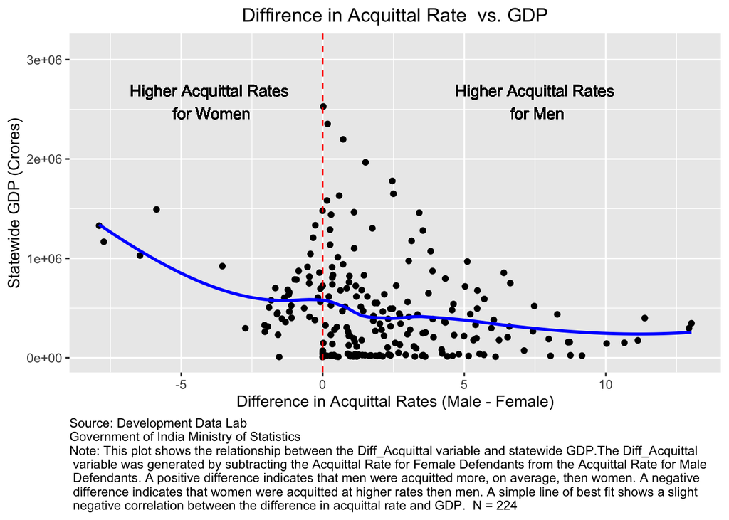

This plot shows that the majority of states have higher acquittal rates for men than women, as the majority of data points are concentrated on the right side of the graph. On this side of the graph, there appears to be a negative relationship between the difference in acquittal rates and GDP, meaning that areas with more equal acquittal rates tend to display a higher GDP. This would support my hypothesis, as it would predict that lower judicial bias is indicative of economic growth. However, it is important to note that this relationship is not necessarily linear, which I will examine in my analysis. There appears to be a slight U-shape which begins at the point where the difference between the male and female acquittal rates is zero.

GDP and Difference in Acquittal Rate

|  | (1) |
| --- | --- |
| (Intercept) | 550805.308*** (36284.106) |
| diff_acquittal | −39791.832*** (9680.203) |
| Num.Obs. | 224 |
| R2 Adj. | 0.067 |

From my first regression model, we can see that the estimated decrease in GDP for each unit that the acquittal rate moves closer to a higher male acquittal bias is approximately 39,791 crore. Given the fact that the mean GDP across Indian states was approximately 607,560 crore, this is a pretty substantial effect. Furthermore, the test shows a statistically significant result. Furthermore, the intercept is 550805. The R squared value is 0.067, indicating that about 6.7% of the variability in GDP can be explained by the variance in the difference in acquittal rates between males and females in this model. Considering the number of factors that can influence GDP, in this context, 7% of the variability in GDP being explained by the difference in acquittal rate is quite substantial.

GDP and Difference in Acquittal Rate, squared

|  | (1) |
| --- | --- |
| (Intercept) | 545782.952*** (36255.732) |
| diff_acquittal | −56614.192*** (13860.576) |
| diff_acquittal_squared | 2788.757+ (1650.999) |
| Num.Obs. | 224 |
| R2 Adj. | 0.074 |

When I attempt to model the U-Shape by including a squared term, we can see that there is a slightly larger coefficient on the diff_acquittal variable, with a one unit move towards a higher acquittal rate for men leading to a 56,614 crore decrease in GDP. The intercept is almost the same, with the model predicting that when there is no difference in acquittal rates (no bias) the state’s GDP will be approximately 545,782 crores. Additionally, the r-squared value is slightly higher in this model, with a value of 0.074 indicating that 7.4% of the variability in GDP can be explained by variability in the difference in acquittal rate when attempting to control for the U-shape. This is even stronger, suggesting that this relationship is indeed non-linear, as this model is a better fit.

GDP and Difference in Acquittal Rate with Control

|  | (1) |
| --- | --- |
| (Intercept) | 453655.596*** (107304.054) |
| diff_acquittal | −41698.283*** (10087.691) |
| pop_growth | 8122.532 (8207.835) |
| Num.Obs. | 213 |
| R2 Adj. | 0.067 |

# Empirical Extension Findings

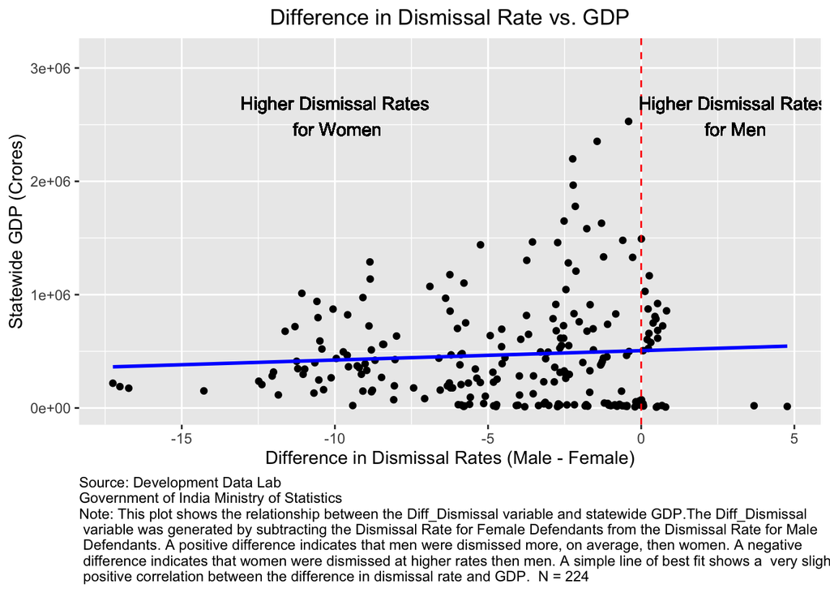

This plot shows that the majority of states have higher dismissal rates for women than men, as the majority of data points are concentrated on the left side of the graph. On this side of the graph, there appears to be a slight positive relationship between the difference in dismissal rates and GDP, meaning that areas with more equal dismissal rates tend to display a higher GDP. This would support my hypothesis, as it would predict that lower judicial bias is indicative of economic growth.

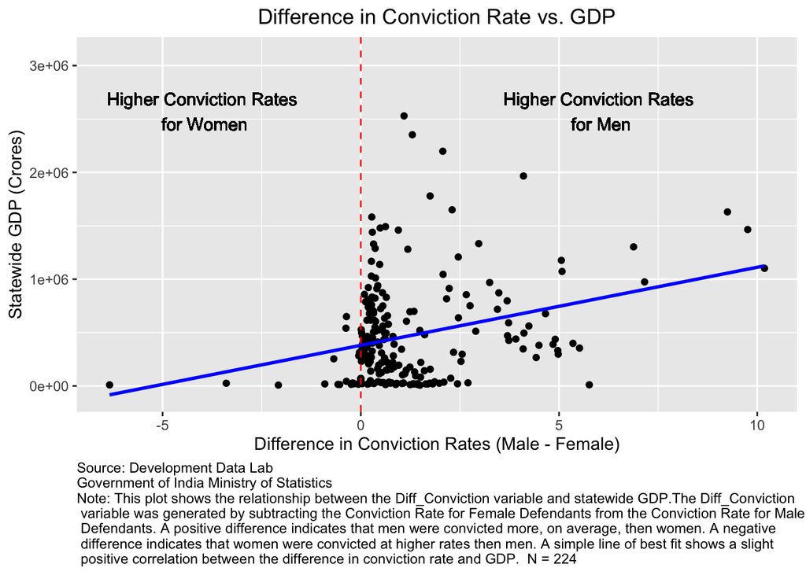

This plot shows that the majority of states have higher conviction rates for men than women, as the majority of data points are concentrated on the right side of the graph. On this side of the graph, there appears to be a slight positive relationship between the difference in conviction rates and GDP, meaning that areas with more disparate conviction rates tend to display a higher GDP. This would not support my hypothesis. However, in this plot, unlike the others, we can see that a large number of data points are closer to 0 - meaning that conviction rates are usually more equal for men and women compared to other measures.

GDP and Difference in Dismissal Rate

|  | (1) |
| --- | --- |
| (Intercept) | 506145.604*** (46425.104) |
| diff_dismissal | 8285.410 (7806.279) |
| Num.Obs. | 224 |
| R2 Adj. | 0.001 |

For my first empirical extension, I looked at the relationship between GDP and the difference in dismissal rates between men and women. It appears that for every one unit change towards a higher dismissal rate for men, there is an 8285 crore increase in GDP. However, these results are not statistically significant, and the magnitude of the results are not large. Furthermore, the R-squared is extremely small, with a mere 0.1% of variation in GDP being explained by the variance of the difference in dismissal rate.

GDP and Difference in Conviction Rate

|  | (1) |
| --- | --- |
| (Intercept) | 380627.558*** (36115.715) |
| diff_conviction | 73096.812*** (16115.072) |
| Num.Obs. | 224 |
| R2 Adj. | 0.081 |

Next, I looked at the relationship between GDP and the difference in conviction rates between men and women. The model indicates that a one unit increase towards a higher conviction rate for men is indicative of an increase in the GDP of 73,096 crore. These results are both significant and of a substantial magnitude. Furthermore, the R squared value indicates that about 8% of the variation in GDP can be explained by the difference in conviction rates.

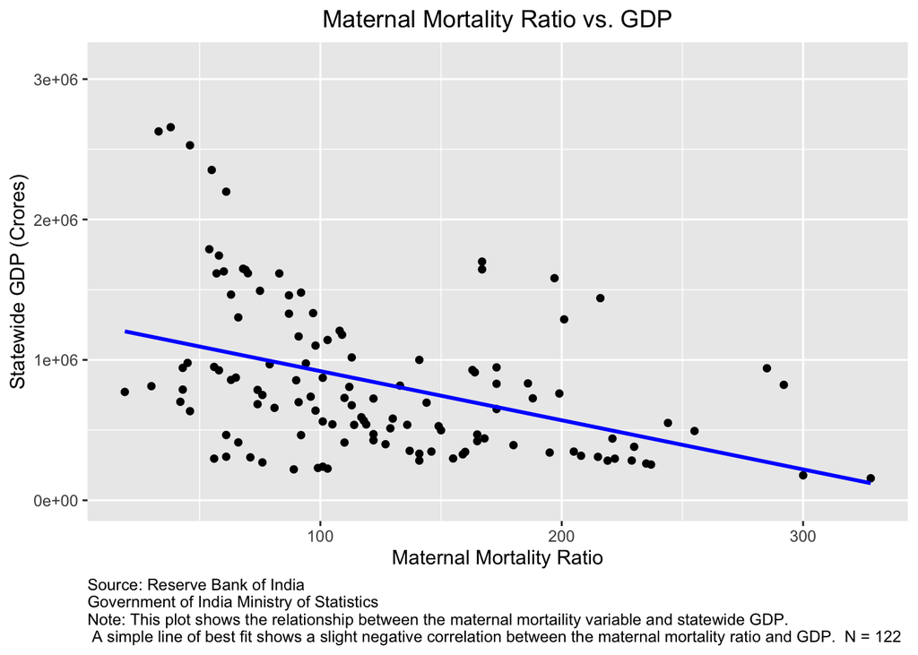

[figure not shown]

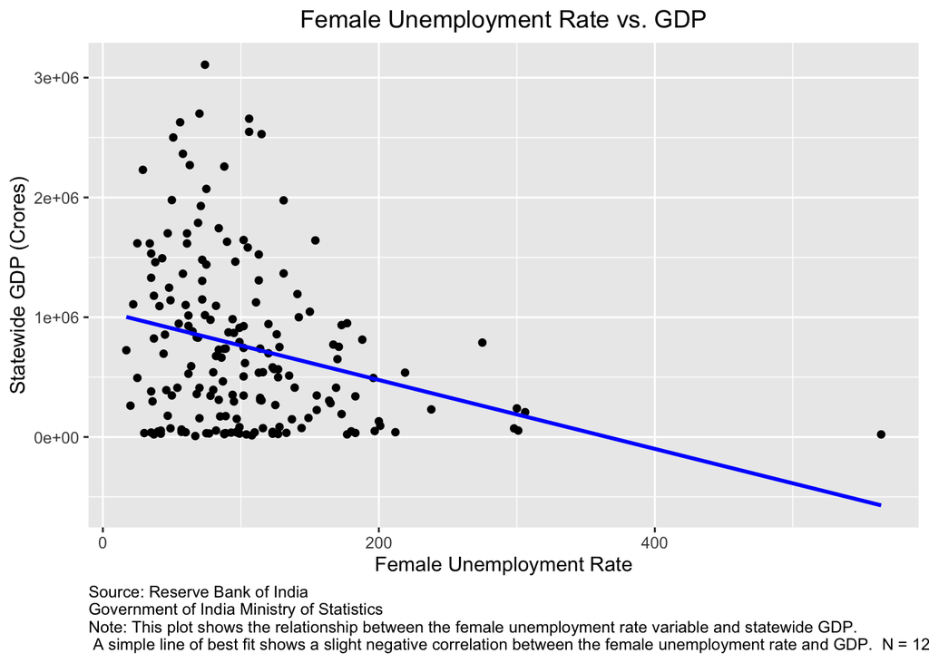

GDP and Maternal Mortality Ratio

|  | (1) |
| --- | --- |
| (Intercept) | 1269955.368*** (98208.762) |
| mmr | −3500.283*** (699.311) |
| Num.Obs. | 122 |
| R2 Adj. | 0.166 |

GDP and Total Fertility Rate

|  | (1) |
| --- | --- |
| (Intercept) | 1119940.764*** (143665.522) |
| tfr | −201453.223** (65800.551) |
| Num.Obs. | 204 |
| R2 Adj. | 0.040 |

GDP and Female Unemployment Rate

|  | (1) |
| --- | --- |
| (Intercept) | 1051265.823*** (94475.724) |
| unemr | −2875.418*** (766.299) |
| Num.Obs. | 180 |
| R2 Adj. | 0.068 |

Finally, I tested three different indicators of gender outcomes in society in order to compare and contrast them with the access to justice variables. All three increases lead to decrease in GDP, as predicted. Furthermore, all three indicators are significant. However, the total fertility rate appears to have an effect of much greater magnitude on the GDP, with a one unit increase (one child increase) in the total fertility rate resulting in a 201,453 crore decrease in the GDP.

# Discussion and Policy Implications

My findings indicate that a greater male bias in acquittals is related to lower GDP levels, which supports my hypothesis that lower judicial biases will result in higher levels of GDP, and supports the idea that women contribute positively to the growth of society when they are allowed the tools and resources to do so. Furthermore, this result holds when controlling for statewide population growth as well. However, I did not find any significant results when examining the difference in dismissals, which indicates that different judicial bias measures may yield different results. This is supported by the idea that for conviction rates, higher male conviction rates were indicative of a higher GDP. There are many reasons why such variation may be the case. One, it may be due to a composition effect, where cases that are brought against women are usually lower severity crimes, and therefore result in far less convictions, with little effect on GDP. Furthermore, this may also be caused by the many unobserved potential confounders, which was the greatest limitation of this study. Due to the limited data available, it was not possible to test for many confounders at the state level specifically. Therefore, as an extension to this project, it would be worthwhile to gather both data and knowledge surrounding other facets of the Indian judiciary, as well as border law enforcement. Additionally, it might be interesting to conduct this study in a different country where there is a similar state structure but more data available.

My results are further substantiated by the three indicators of gender bias in a society and their relationship with GDP. As an increase in all three is associated with a decrease in the GDP, one can safely conclude that there is a relationship between gender bias as a whole and with economic growth. Although my results indicate that this may also be true at the judicial level specifically, it is worthwhile to dive deeper into the specific mechanisms that may relate judicial outcomes and growth.

Overall, the implications for policy suggest a greater need to invest in women’s access to justice in India. Although further research may be needed to specifically determine the affects on GDP, women’s access to justice remains a human right, and therefore governments should take steps to:

- Ensure increased transparency in judicial decisions with female defendants
- Ensure bias training for judges
- Ensure women have safe and easy access to the courts.

# Appendix:

## References

2024. *GIWPS*. Georgetown Institute for Women, Peace; Security. https://giwps.georgetown.edu/the-index/.

———. n.d.b. *UN Women*. https://www.unssc.org/sites/default/files/UNWomenFactSheet.pdf.

———. n.d.a. *United Nations*. United Nations. https://www.un.org/en/about-us/universal-declaration-of-human-rights.

Ash, Elliot, Sam Asher, Aditi Bhowmick, Sandeep Bhupatiraju, Daniel Chen, Tanaya Devi, Christoph Goessmann, Paul Novosad, and Bilal Siddiqi. 2023. “In-Group Bias in the Indian Judiciary.”

Badoni, Priyansha, and Faizanur Rahman. 2022. “Judicial Stereotyping in Sexual Violence Cases and Secondary Victimization of Women in India.”

Dam, Kenneth. 2016. “The Judiciary and Economic Development.” *Brookings*. https://www.brookings.edu/articles/the-judiciary-and-economic-development/.

Deseau, Arnaud, Adam Levai, Michèle Schmiegelow, et al. 2019. “Access to Justice and Economic Development: Evidence from an International Panel Dataset.” Institut de recherches économiques et sociales de l’Université catholique de ….

Garg, Sudha et al. 2024. “Role of Indian Judiciary in Empowerment of Women: An Analysis Through Case Laws.” *Educational Administration: Theory and Practice* 30 (4): 6473–84.

Holland, Dawn, and Katrina Ell. 2023. “Close the Gender Gap to Unlock Productivity Gains,” March. https://www.moodysanalytics.com/-/media/article/2023/Close-the-Gender-Gap-to-Unlock-Productivity-Gains.pdf.

Jassal, Nirvikar. 2023. “Does Victim Gender Matter for Justice Delivery? Police and Judicial Responses to Women’s Cases in India.” *American Political Science Review*, 1–27.

Lorizio, Marilene, and Antonia Rosa Gurrieri. 2014. “Efficiency of Justice and Economic Systems.” *Procedia Economics and Finance* 17: 104–12. https://doi.org/10.1016/s2212-5671(14)00884-3.

Sandefur, Rebecca L. 2008. “Access to Civil Justice and Race, Class, and Gender Inequality.” *Annual Review of Sociology* 34 (1): 339–58. https://doi.org/10.1146/annurev.soc.34.040507.134534.

Verma, Sonali. 2024. “India Records 51 Cases of Crime Against Women Every Hour; over 4.4 Lakh Cases in 2022: NCRB Report.” *The Times of India*. TOI. https://timesofindia.indiatimes.com/india/india-records-51-cases-of-crime-against-women-every-hour-over-4-4-lakh-cases-in-2022-ncrb-report/articleshow/105731269.cms?utm_source=contentofinterest&utm_medium=text&utm_campaign=cppst.